# Machine Learning to Predict College Crime Rates

#### Authors: Kelsey Aiello, Xiaowen Feng, Riley Andert, Randi Mendel

[Code Resource](https://github.com/randimendel95/Info370-Final-Project)

## Introduction

Of all criminal incidents reported to the National Incident-Based Reporting System (NIBRS), 3.3% took place on a college campus. College is an important space where students are given the opportunity for higher knowledge and learning as they transition to a more independent state. However, crime at such institutions is an issue for students and parents alike, as well as officials who work to mitigate such crimes. Colleges invest significant amounts of money in preventing crime, but data relevant to campus crime is often only reported as a historical, after-the-fact statistics. Being able to use data about colleges as a predictor of criminal offenses could help college officials develop plans to reduce crime rates. Through our study we hope to provide officials with this data, and also offer it to students as it may impact their decision on which school to attend.

## Introduction to Dataset

Our research question was **how can different information about a college allow us to predict crime rate for a college?** We found two datasets that we combined in order to get a holistic view of school information compared to crime statistics for that school.

1. Campus safety and security dataset, including number of criminal offense occurrences in each school in 2014.
2. College Scorecard dataset, was consist of a wide range of data element about a school (average cost of attendance, average faculty salary, etc.).

Below is a sample of our final dataset.

|  | UNITID | INSTNM | crime_rate | student_pop | control | fin_indep | pre_degree | firstgen_pct | fam_income | sector |
| --- | --- | --- | --- | --- | --- | --- | --- | --- | --- | --- |
| 0 | 100654 | Alabama A & M University | 3.562723 | 5333 | 1 | 0.129593 | 3 | 0.394034 | 21595.33200 | Public |
| 1 | 100663 | University of Alabama at Birmingham | 1.604450 | 18698 | 1 | 0.311615 | 3 | 0.357159 | 34491.40120 | Public |
| 2 | 100690 | Amridge University | 0.000000 | 625 | 2 | 0.894260 | 3 | 0.602410 | 15191.78276 | Private Non-Profit |
| 3 | 100706 | University of Alabama in Huntsville | 4.627109 | 7348 | 1 | 0.348569 | 3 | 0.342919 | 36239.77182 | Public |
| 4 | 100724 | Alabama State University | 15.038956 | 5519 | 1 | 0.143531 | 3 | 0.380558 | 21737.27737 | Public |

Note that, sector and control are both representations of type of sector for an insitutition. Control encoded the sector where 1 represents public colleges, 2 represents private non-rofit colleges and 3 for private for-profit colleges.

## Description of Variables

```
count    5791.000000
mean        2.719362
std         9.763514
min         0.000000
25%         0.000000
50%         0.000000
75%         2.007121
max       281.250000
Name: crime_rate, dtype: float64
```

The factors we chose to include were the ones that we found to have a significant impact on our model. One primary factor that influenced our variable choice was availability, as some features contained a lot of null values. Another influencing factor was an exploratory data analysis where we noticed a high correlation between certain variables and crime rate. We then narrowed them further by selecting which variables followed our goals for the project, this left us with the below variables.

The table below shows variables we used in our research.

| Variable Type | Name | Data Type | Explanation |
| --- | --- | --- | --- |
| Outcome | crime_rate | double | Number of offenses per 1,000 population |
| Feature | sector | factor | Institution sector |
| Feature | fam_income | int | Average family income |
| Feature | pre_degree | factor | Predominant degree awarded (recoded from 0 to 4) |
| Feature | fin_indep | factor | Average rate of financial independent students |
| Feature | firstgen_pct | factor | Percentage of first generatation students |

The predominant degree is encoded into 0 - 4, the score detail is shown below.

| Predominat Degree | Representation |
| --- | --- |
| 0 | Not classified |
| 1 | Predominantly certificate-degree granting |
| 2 | Predominantly associate's-degree granting |
| 3 | Predominantly bachelor's-degree granting |
| 4 | Entirely graduate-degree granting |

In our exploratory data analysis we delve into the distribution of our chosen variables. Below is a graph of the distribution of one of these variables. As you can see there are a high number of occurrences that fall in the zero category and then there is a very slight tail to the right. This showed us that the data follows a poisson distribution. We also noticed in this dataset that there were a few major outliers that had a very large number of crimes and a low number of students which skewed our data. We removed these outliers from our training set as we did not think it represented the trends of the data overall.

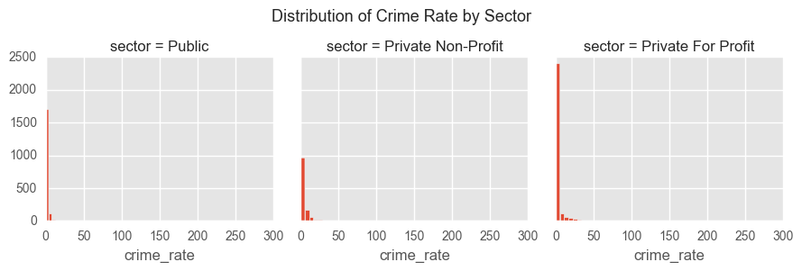

We also encountered some limitations in our dataset. As seen in the graph below there were a large number of private schools compared to other types of colleges.

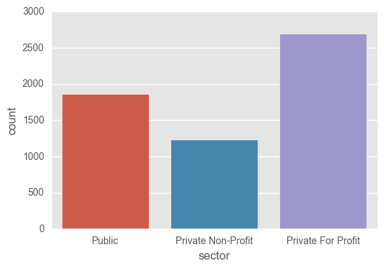

Below is a visualization that demonstrates some of the outliers we encountered. It also demonstrates how having the higher number of private schools makes the private schools appear to have higher crime rates and could slightly skew our results.

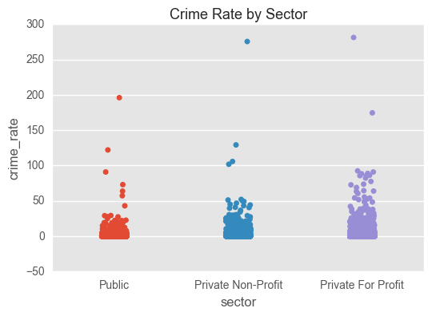

## Introduction to K-Nearest-Neighbors (KNN)

K-nearest-neighbors (KNN) is a robust algorithm used to classify data. KNN falls in the supervised learning family of algorithms. In order to use KNN, we are given a labelled dataset consisting of training observations (x, y) and would like to capture the relationship between x and y. In this example we will use x to denote a *feature* (i.e., an attribute, what we are using to predict) and y to denote the *outcome* we are trying to predict.

In the classification setting, the K-nearest neighbor algorithm essentially boils down to forming a majority vote between the K most similar instances to a given “unseen” observation. One of the pros of using a KNN model is that it can learn complex decision boundaries on the fly. However, it is worth noting that the minimal training phase of KNN comes both at a *memory cost*, since we must store a potentially huge data set, as well as a *computational cost* during test time since classifying a given observation requires a run down of the whole data set.

## Apply KNN to Our Dataset

Now that we have explained KNN is is important to explain how that links with our data. We ended up with 5,791 colleges which were used to create our model. We split this data into 80% training, and 20% test data, then ran 10-fold cross validation using a k nearest neighbors algorithm to find the colleges that had the most similar attributes to a particular college in question, and tested this with multiple values of the most similar colleges, by averaging their crime rates. We used 5 features to measure similarity between colleges: percentage of financially independent students, percent of first generation college students, average family income, control of the institution(private or public), and the predominant degree achieved by students. Once we normalized these features from the minimum value to the maximum on a scale of 0 to 1, we used our algorithm to find the sum of distances of each feature between each college in the training set to our test value, in order to find the values with the least difference in feature to the college in question. We ran this using several different numbers of neighbors, and found the root mean squared error in our predictions for each test set in our 10 folds, and found the average error in our predictions, choosing the number of compared neighbors with the least error in prediction.

As shown below, somewhere around **250 neighbors** would be our ideal K neighbors, however this model may not be accurate since this large number means that it is likely that neighbors with similar attributes don't actually tend to have the same crime rates, based on our given data, with only the given attributes weighted equally.

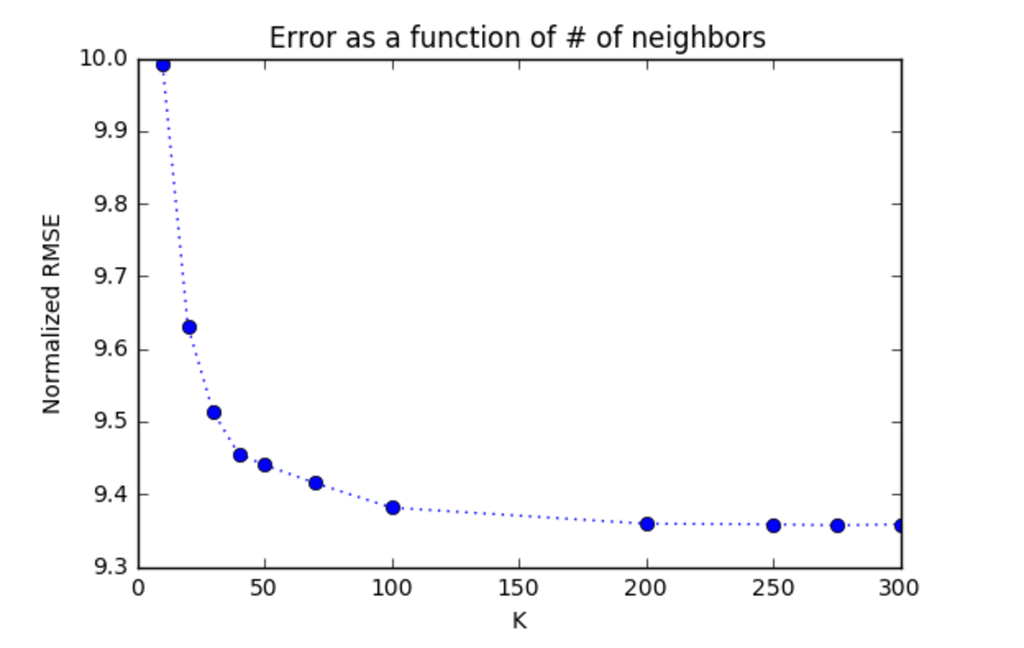

## Limitations

Our dataset had some inherent limitations, the greatest of which is the fact that it relies on reports from different sources. In some cases crime incident reports may have come from schools self-reporting, while in others they may have come from local law enforcement. In some instances schools did not report data. Additionally, schools are located in different states and local jurisdictions which may have different definitions of criminal offences. For instance, substances which may result in a drug-related criminal arrest at colleges located in one state may be legal in others.

Our dataset was also relatively small (~5,000 rows) for the type of predicting we aimed to do. We may have been able to predict more accurately with additional data. Lastly, we only analyzed five different features to predict crime rate. We therefore acknowledge that the predictions we made may not be accurate as there are many other factors that come into play.

## Discussion

Using our model we built we can now predict a college’s crime rate based on the five variables we used. This information could be used by students in high school looking to avoid schools who may have a higher crime rate. We chose to focus, for this first iteration of our project, on total crimes, cumulated for a college, however this could be extended to more common crimes such as liquor law violations, or more serious and violent crimes alike in order to predict which crimes may be present at a particular college, if these results may differ more with different features of a school.